# “EDRM 718 Assignment 9”

“Hongxiao Yu”

“13 April 2020”

This is part 1 of the assignement 9 #log in data first

```r
library(tidyverse)
library(here)
abuse <- read_csv(here("Data","Sexual Abuse Data.csv"))
```

# make csa as a facter

```r
abuse$csa <- factor(abuse$csa,
                      levels = c("Abused", "NotAbused"),
                      labels = c("Abused", "NotAbused"))
```

#1 # Create a graph to compare the PTSD scores of women # who suffered childhood sexual abuse to those # who did not suffer childhood sexual abuse.

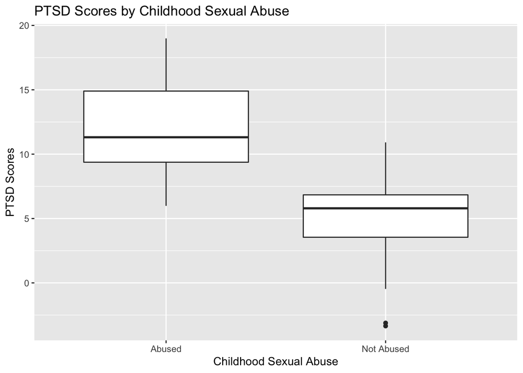

```r
ggplot(abuse, aes(x = csa, y = ptsd)) +
  geom_boxplot() +
  labs(x= "Childhood Sexual Abuse", y = "PTSD Scores",
        title = "PTSD Scores by Childhood Sexual Abuse") +
  scale_x_discrete(labels = c('Abused', 'Not Abused'))
```

#2 # Create a graph to compare the childhood physical abuse scores of women # who suffered childhood sexual abuse to those who did not suffer # childhood sexual abuse.

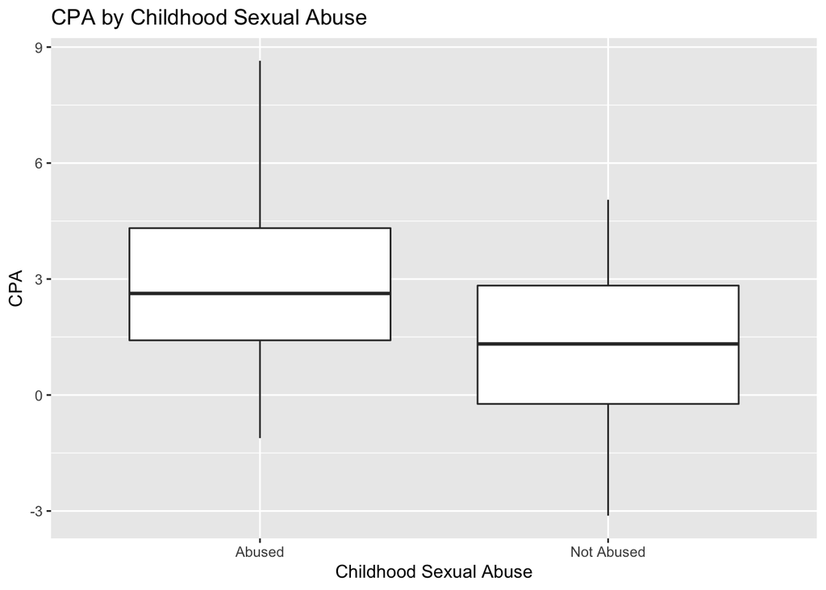

```r
ggplot(abuse) +
  geom_boxplot(mapping = aes(x = csa, y = cpa)) +
  labs(x= "Childhood Sexual Abuse", y = "CPA",
        title = "CPA by Childhood Sexual Abuse") +
  scale_x_discrete(labels = c('Abused', 'Not Abused'))
```

#3 Create a scatterplot that relates PTSD scores (the response variable) to childhood physical # abuse scores (the explanatory variable). Use different types of points and colors to # differentiate between the women who suffered childhood sexual abuse and those who did not # suffer childhood sexual abuse. Put two linear regression lines on your plot to relate PTSD # to childhood physical abuse separately for those who suffered childhood sexual abuse and # those who did not. Use the same color as the related points for the regression lines to # make it obvious which points relate to which group

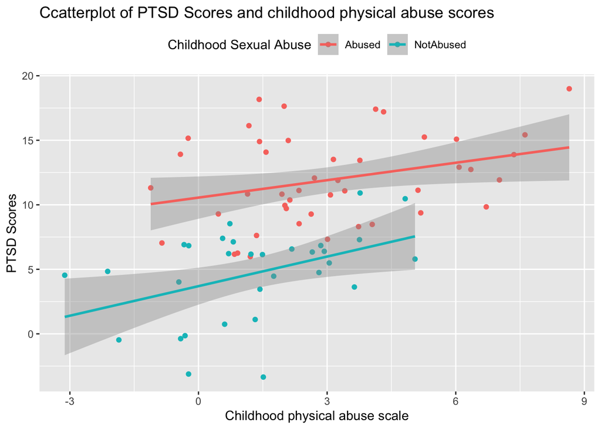

```r
ggplot(abuse, aes(x = cpa, y = ptsd)) +
  geom_point(mapping = aes(color = csa)) +
   labs(x= "Childhood physical abuse scale", y = "PTSD Scores",
        color = "Childhood Sexual Abuse",
        title = "Ccatterplot of PTSD Scores and childhood physical abuse scores") +
  theme(legend.position = "top") +
  stat_smooth(method = "lm", mapping = aes(color = csa))
```